# Determinantes de la felicidad a nivel global (2016)

Guillermo Coronado

25/6/2022

# **Introducción**

En este trabajo, se buscará explicar el nivel de felicidad a nivel global durante el año 2016. Para ello, propondremos tres modelos de regresión lineal múltiple que contengan algunos de sus principales determinantes a nivel agregado (es decir, características por país, no individuales), para, tras una comparación, elegir el modelo más pertinente para explicar la felicidad . Para ello, trabajaremos con indicadores del Banco Mundial y de la encuesta sobre felicidad extraída de “Our World in Data”.

# **Variables independientes**

Para explicar la varianza del indice de felicidad, nos centraremos en sus determinantes “económicos”, con lo cual el presente trabajo se inscribe dentro del campo de estudio de la “Economía de la felicidad” (Días, 2013). Dentro de este campo existe un amplio cuerpo de literatura que discute los principales determinantes de la felicidad, así como las mejores metodologías econométricas para explicar este fenómeno. El principal debate se da en torno a la importancia del ingreso (tanto a nivel individual como de país) en la explicación de la felicidad, a partir de lo que se conoce como la “paradoja de Easterline”. Esta paradoja consiste en que, mientras que, “en los estudios transversales al interior de los países hay una clara indicación acerca de que el ingreso y la felicidad están positivamente asociados, esto no sucede cuando se compara entre países ni en los estudios a nivel de país con series temporales (Dias, 2013, p.10). Una explicación a este fenómeno es que, al parecer, mientras que el ingreso afecta de manera positiva la sensación de bienestar en los países en desarrollo, se llega a un”punto de saciedad” en los países industrializados, en donde el ingreso pasaría a tener un efecto negativo sobre la felicidad o dejaría de tener un efecto significativo (García, 2018, p.7). Sin embargo, esta hipótesis está a debate debido a que existiría evidencia de que el ingreso se relaciona de manera positiva con el nivel de felicidad en todos los países, sin importar si estos son “desarrollados” (Stevenson y Wolfers, 2008, citados en Garcia, 2018, p.7). Sumado a ello, otra variable que al parecer ha demostrado tener un efecto significativo (aunque negativo) en el nivel de felicidad es el nivel de desempleo por país, debido a que existiría un “costo psicológico” causado por el desempleo o, en otras palabras, un “miedo al desempleo” (Garcia, 2018, p.8)

Debido a la importancia que tienen estas dos variables en el debate sobre el tema, utilizaremos el PBI per cápita y el porcentaje de desempleo sobre el total de la fuerza laboral (los estimados por la OIT, para evitar posibles problemas de manipulación de datos por parte de los gobiernos) como variables predictoras en nuestros modelos. En un primer modelo, incluiremos la variable PBI per capita para poner a prueba si esta afecta de manera significativa y directa el nivel de felicidad. Asimismo, añadiremos la variable porcentaje de desempleo para poner a prueba si esta tiene, por el contrario un efecto inverso sobre el nivel de felicidad. En un segundo modelo, utilizaremos nuevamente el PBI per capita como variable predictora, pero añadiremos un efecto cuadrático a esta variable para comprobar si existe este “punto de saciedad” en el sentido especiifcado anteriormente. En un tercer modelo, mantendremos las dos variables usadas en el segundo, pero añadiremos nuevamente el porcentaje de desempleo. En todos los casos, la elección de las variables independientes se justifica debido a que son fuentes de debate en la literatura académica de este campo de estudio, por lo cual, utilizarlas permitirá poner a prueba las posiciones en disputa por lo menos para el caso del año 2016 a nivel global.

## **Análisis univariado**

A continuación, pasaremos a presentar el comportamiento de nuestra variable dependiente y de nuestras variables independientes.

### **Felicidad**

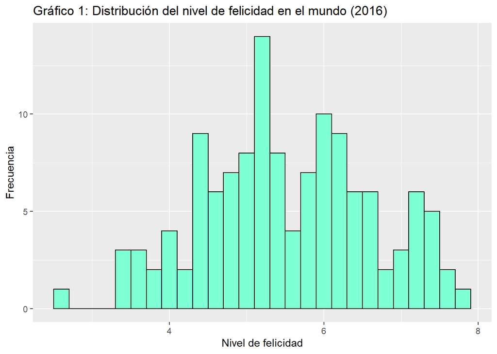

### **PBI per cápita**

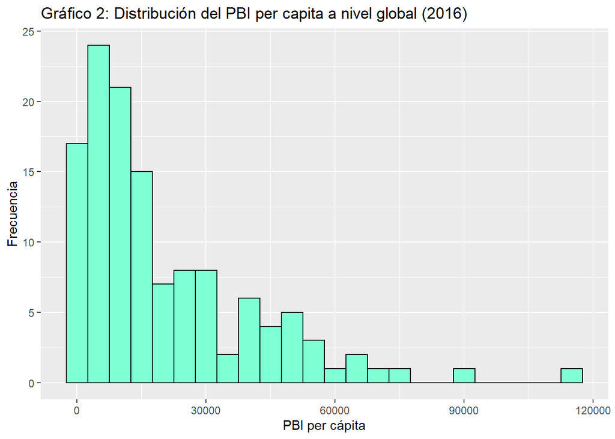

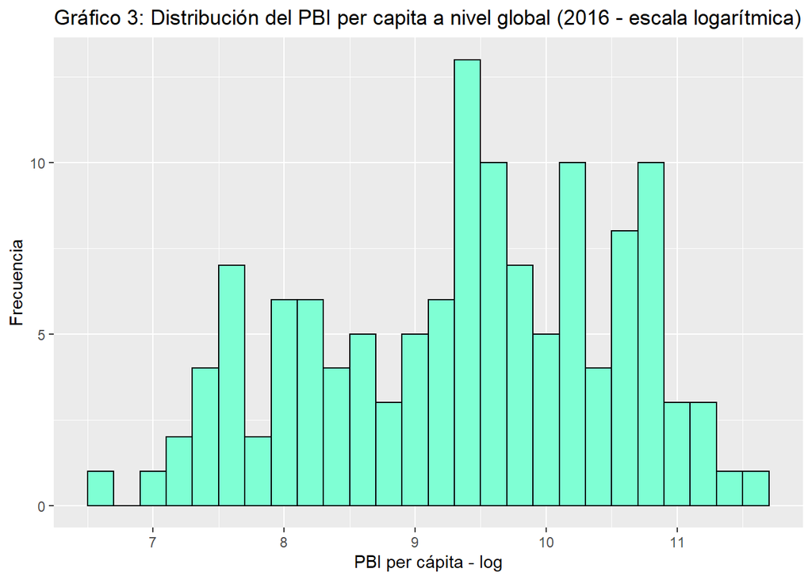

### **Porcentaje de desempleados sobre el total de la fuerza laboral**

[figure not shown]

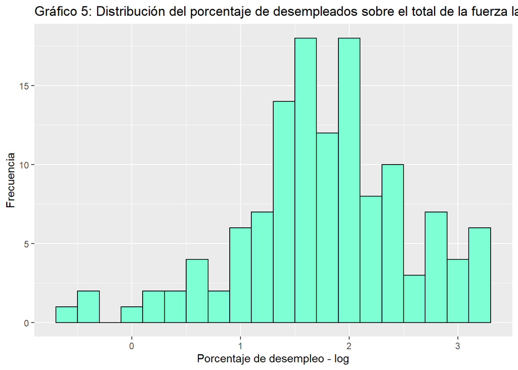

### **Resumen de estadísticos descriptivos**

**Tabla 1: Estadísticos descriptivos**

| Statistic | N | Mean | St. Dev. | Min | Max |
| --- | --- | --- | --- | --- | --- |
| Nivel de felicidad | 128 | 5.529 | 1.087 | 2.694 | 7.858 |
| PBI per capita | 127 | 20,366.220 | 20,469.870 | 794.604 | 113,035.800 |
| PBI per capita log | 127 | 9.371 | 1.151 | 6.678 | 11.635 |
| Porcentaje de desempleo | 127 | 7.643 | 5.772 | 0.534 | 26.540 |
| Porcentaje de desempleo log | 127 | 1.765 | 0.772 | -0.627 | 3.279 |

## **Análisis bivariado**

### **Felicidad según PBI per cápita**

El **Gráfico 6** nos muestra la dispersión de los niveles de felicidad en el mundo según el PBI per cápita del país. A simple vista, podemos observar que, conforme aumenta el PBI per capita, auementa también el nivel de felicidad, con lo cual estamos frente a una relación directa entre ambas variables. Esto se comprueba si observamos la **Tabla 2**, que nos muestra una fuerte correlación (0.791) entre ambas variables. Asimismo, el gráfico no muestra una tendencia a que el nivel de felicidad empiece a disminuir entre los países con un mayor PBI per cápita, es decir, no observamos el llamado “punto de saciamiento” que algunos autores notaban. Por el contrario, el nivel de felicidad parece ser mucho mayor en los países de mayor ingreso

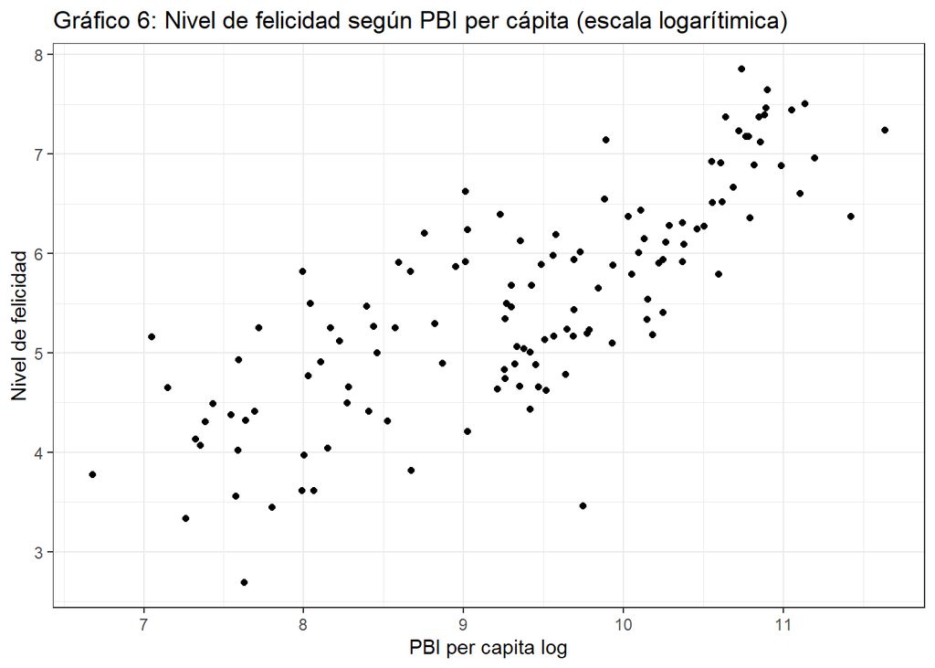

### **Felicidad según porcentaje de fuerza laboral desemplead**

El **Gráfico 7** nos muestra los niveles de felicidad en el mundo según el porcentaje de la fuerza laboral desempleada que tiene cada país. A simple vista, el gráfico no nos permite ver ninguna relación significativa entre ambas variables. Esto se comprueba al ver que la correlación es solo de 0.047 (ver **Tabla 2**), con lo cual, parece ser falso el hecho de que, a mayor desempleo hay menores niveles de felicidad en promedio, como algunos autores habían hallado.

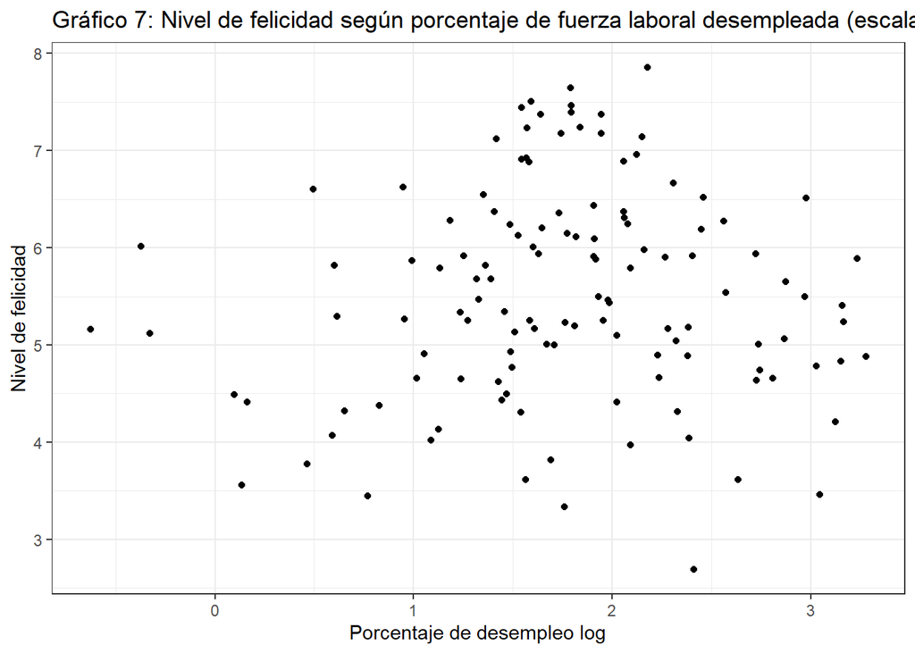

**Tabla 2: Matriz de correlaciones**

|  | Nivel de felicidad | PBI per capita log | Porcentaje de desempleo log |
| --- | --- | --- | --- |
| Nivel de felicidad | 1 | 0.791 | 0.047 |
| PBI per capita log | 0.791 | 1 | 0.353 |
| Porcentaje de desempleo log | 0.047 | 0.353 | 1 |

# **Modelos**

Como señalamos, plantearemos tres modelos de regresión lineal múltiple que tienen como objetivo explicar la varianza del nivel de felicidad a nivel global

## **Modelo 1**

El primer modelo toma la siguiente forma:

$$Felicidad = B_0 + B_1 * PBI per cápita
log + B_2 * Desempleolog$$

En este modelo, esperaríamos que el PBI per cápita (en escala logarítimica) tenga un efecto positivo en la felicidad, es decir, que a mayor PBI per cápita, habrá, en promedio, mayores niveles de felicidad. Asimismo, esperamos que el porcentaje de la fuerza laboral desempleada (en escala logarítimica) tenga un efecto negativo en el nivel de felicidad, es decir que, a mayor desempleo, el nivel de felicidad disminuirá.

## **Modelo 2**

El segundo modelo toma la siguiente forma:

$$Felicidad = B_0 + B_1 * PBI per cápita
log + B_2 * (PBI per cápita log)^2$$

En este modelo estamos incluyendo nuevamente el PBI per cápita en escala logarítimica como variable explicativa de la felicidad; sin embargo, estamos añadiendo un efecto cuadrático en esta variable, ya que, como dijimos, en base a la revisión de la literatura esperaríamos que el PBI per cápita tenga un efecto positivo en la felicidad hasta llegar a un punto en el que pasaría a tener un efecto negativo, en especial en los países de mayor ingreso per cápita. Es decir, esperaríamos una función convexa.

## **Modelo 3**

El último modelo que estamos proponiendo toma la siguiente forma:

$$Felicidad = B_0 + B_1 * PBI per cápita
log + B_2 * (PBI per cápita log)^2 + B_3*Desempleolog$$
En este último modelo estamos incluyendo las dos variables del modelo 2, esperando que se relacionen de la misma manera con nuestra variable dependiente. No obstante, en este modelo añadimos el porcentaje de la fuerza laboral desempleada como variable explicativa, esperando, nuevamente, que tenga un efecto negativo sobre el nivel de felicidad.

# **Resultados de modelos de regresión**

La **Tabla 3** nos muestra los resultados de nuestros tres modelos de regresión lineal múltiple. Lo primero que podemos observar es que, en nuestro primer modelo, tanto el PBI per cápita como el desempleo se relacionan significativamente con nuestra variable dependiente. En ambos casos, tenemos un 99% de confianza en que su efecto en el nivel de felicidad es distinto a cero. En cuanto al PBI per cápita, vemos que por cada aumento de esta variable en un 1%, el nivel de felicidad aumenta, en promedio, 0.00837 puntos. El porcentaje de desempleados, por el contrario, se relaciona de manera inversa con el nivel de felicidad, ya que, con cada aumento en una unidad porcentual de aquella variable, el nivel de felicidad disminuirá, en promedio, 0.00373 puntos. Como dicha variable ya se encuentra en unidades porcentuales (estamos hablando del porcentaje del porcentaje), podemos decir directamente que un aumento de 1% en el nivel de trabajadores desempleados disminuye, en promedio, el nivel de felicidad en 0.373 puntos. Así, por ejemplo, de acuerdo a los valores predichos por nuestro modelo, un país como Afganistán, que posee al 11.16% de su fuerza laboral desempleada, tendrá un nivel de felicidad de 3.827 puntos, mientras que, un país como Singapur, con 4.08% de desempleados, tendrá un nivel de felicidad de 7.367 puntos. Por último, vemos que este modelo explica el 68.3% de la varianza del nivel de felicidad, por lo cual consideramos que hemos logrado explicar un amplio porcentaje de este fenómeno con solo dos variables.

**Tabla 3: Resultados de regresión lineal múltiple**

|  | *Dependent variable:* |  |  |
| --- | --- | --- | --- |
|  | Nivel de felicidad |  |  |
|  | Modelo 1 | Modelo 2 | Modelo 3 |
|  | (1) | (2) | (3) |
| PBI per cápita (log) | 0.837*** | -1.381* | -0.189 |
|  | (0.051) | (0.789) | (0.806) |
| % de fuerza laboral desempleada (log) | -0.373*** |  | -0.334*** |
|  | (0.076) |  | (0.082) |
| PBI per cápita (log) 2 |  | 0.116*** | 0.055 |
|  |  | (0.043) | (0.043) |
| Constant | -1.655*** | 8.169** | 2.964 |
|  | (0.451) | (3.597) | (3.651) |
| Observations | 126 | 127 | 126 |
| R<sup>2</sup> | 0.688 | 0.643 | 0.692 |
| Adjusted R<sup>2</sup> | 0.683 | 0.637 | 0.684 |
| Residual Std. Error | 0.615 (df = 123) | 0.657 (df = 124) | 0.614 (df = 122) |
| F Statistic | 135.497*** (df = 2; 123) | 111.638*** (df = 2; 124) | 91.333*** (df = 3; 122) |
| *Note:* | p<0.1; p<0.05; p<0.01 |  |  |

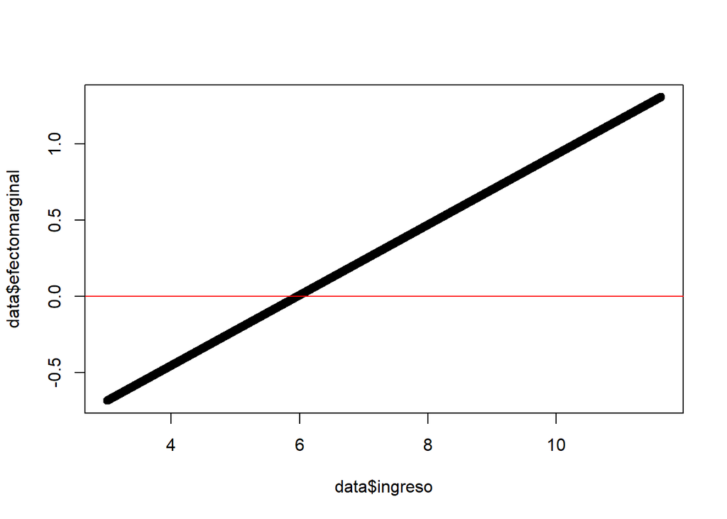

Por último, el modelo 3 incluye las mismas variables que nuestro segundo modelo, pero añadimos nuevamente el porcentaje de fuerza laboral desempleada como predictor. Acá observamos que, con este cambio, el PBI per cápita y el PBI per cápita con su efecto cuadrático dejan de relacionarse de manera significativa con el nivel de felicidad. Esto quiere decir que no estamos seguros de que los coeficientes sean distitos a cero. Igualmente, si hacemos el gráfico del efecto marginal del PBI per cápita al cuadrado sobre el nivel de felicidad, vemos que este efecto aumenta conforme aumenta también el ingreso de los países; sin embargo, a diferencia de en el caso anterior, nunca tiene un efecto negativo (ni siquiera en los países de menores ingresos). A pesar de ello, como dijimos, no podemos confiar en esta estimación. La única variable que posee un efecto significativo en este modelo es precisamente el porcentaje de desempleados, ya que tenemos un 99% de confianza en que su efecto sobre el nivel de felicidad sea distinto a cero. Como esperábamos, esta variable se relaciona de manera inversa con nuestra variable dependiente, ya que, por cada punto porcentual que aumente el desempleo (nuevamente se trata de una variable que ya está en unidades porcentuales), el nivel de felicidad disminuirá en promedio 0.334 puntos. Por último, vemos que este tercer modelo explica el 68.4% de la varianza de nuestra variable dependiente, es decir, tiene un nivel similar de explicación que nuestro primer modelo.

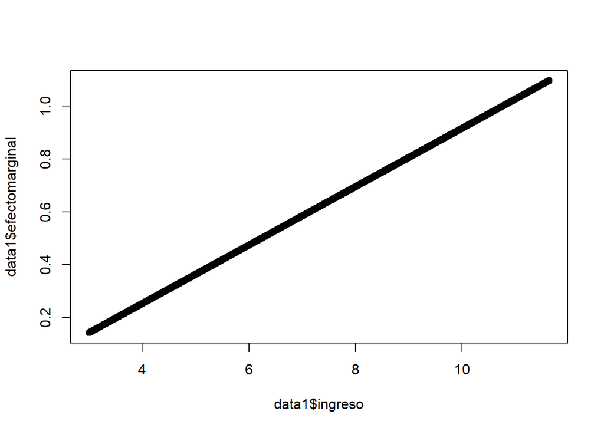

# **Evaluación de modelos**

En esta sección, veremos si nuestros modelos cumplen dos de los supuestos que exige la regresión lineal (no multicolinealidad y homocedasticidad) y también pondremos a prueba si sus residuos se distribuyen de manera normal.

## **Modelo 1**

Empecemos con nuestro primer modelo, el cual incluye como variables independientes el PBI per cápita y el nivel de desempleo (ambos en escala logarítmica). Para el caso de la no multicolinealidad, hemos calculado el coeficiente VIF (factor de inflación de la varianza) que se muestra en la tabla a continuación. Para el caso del modelo 1, vemos que este coeficiente tiene un valor de 1.14, lo cual indica una multicolinealidad moderada, por lo cual, consideramos que este supuesto, dentro de todo, se cumple para este modelo.

[output not shown]

Standard errors: OLS

Pasemos ahora al supuesto de homocedasticidad. A continuación, observaremos un gráfico que nos muestra la distribución de nuestros residuos, los cuales, a simple vista, se distribuyen de manera uniforme por toda la data. Realizamos posteriormente el test de Breusch - Pagan que nos muestra que, efectivamente, nuestro modelo no presenta problema de heterocedasticidad (p = 0.7814, ampliamente mayor a 0.05)

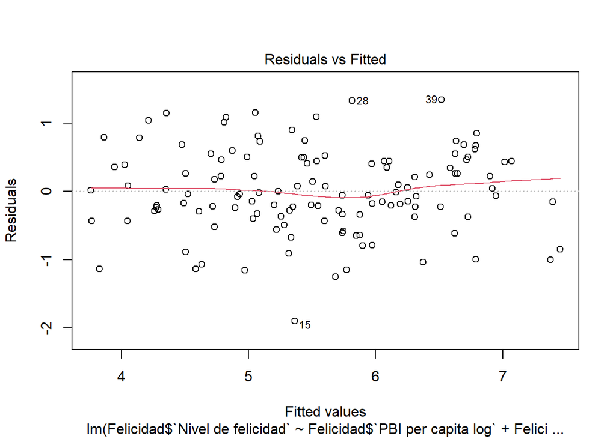

```
##
##  studentized Breusch-Pagan test
##
## data:  modelo1
## BP = 0.49346, df = 2, p-value = 0.7814
```

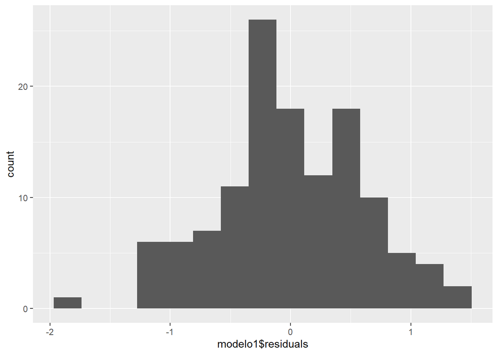

```
##
##  One-sample Kolmogorov-Smirnov test
##
## data:  modelo1$residuals
## D = 0.14247, p-value = 0.01202
## alternative hypothesis: two-sided
```

## **Modelo 2**

Pasemos ahora a nuestro segundo modelo. En este, no realizamos ninguna prueba para el supuesto de no multicolinealidad, ya que, si bien nuestro modelo tiene dos variables independientes, en realidad la segunda no es teóricamente distinta a la primera. En cuanto al supuesto de homocedasticidad, sí realizamos un gráfico de residuos y una prueba de Breusch Pagan. Ambos nos muestran que la varianza de residuos es constante (p= 0.2842), por lo cual no podemos decir que nuestro modelo tiene problemas de heterocedasticidad.

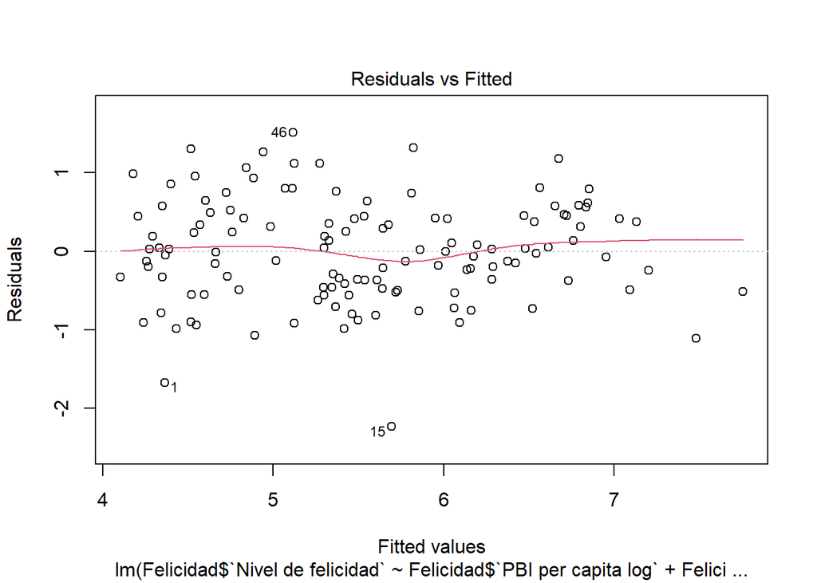

```
##
##  studentized Breusch-Pagan test
##
## data:  modelo2
## BP = 2.5163, df = 2, p-value = 0.2842
```

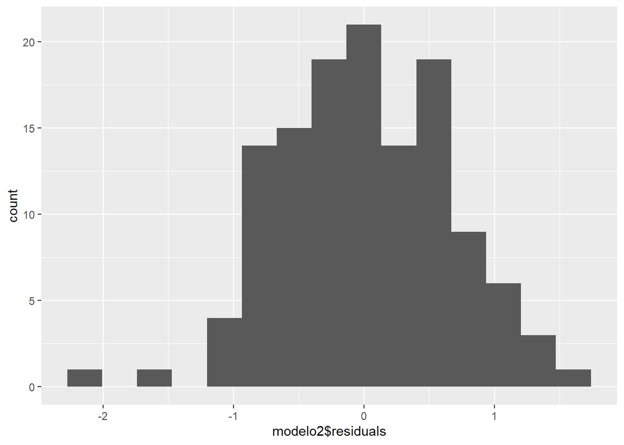

```
##
##  One-sample Kolmogorov-Smirnov test
##
## data:  modelo2$residuals
## D = 0.13012, p-value = 0.02712
## alternative hypothesis: two-sided
```